# SDM_Assignment2_3

Sri Balaji Muruganandam

04/10/2021

### Setting Working Directory

```r
rm(list = ls())
setwd("G:\\SDM_Sem01\\Assignment2")
```

### Importing necessary libraries

```r
library(ggplot2)
library(ISLR)
library(caret)  #Used to perform cross validations
library(glmnet)
data(College)
```

## (a) Split the data set into a training set and a test set. Fit a linear model using least squares on the training set and report the test error obtained.

```r
co_data <-College
names(co_data)
```

```
##  [1] "Private"     "Apps"        "Accept"      "Enroll"      "Top10perc"
##  [6] "Top25perc"   "F.Undergrad" "P.Undergrad" "Outstate"    "Room.Board"
## [11] "Books"       "Personal"    "PhD"         "Terminal"    "S.F.Ratio"
## [16] "perc.alumni" "Expend"      "Grad.Rate"
```

```r
head(co_data)
```

```
##                              Private Apps Accept Enroll Top10perc Top25perc
## Abilene Christian University     Yes 1660   1232    721        23        52
## Adelphi University               Yes 2186   1924    512        16        29
## Adrian College                   Yes 1428   1097    336        22        50
## Agnes Scott College              Yes  417    349    137        60        89
## Alaska Pacific University        Yes  193    146     55        16        44
## Albertson College                Yes  587    479    158        38        62
##                              F.Undergrad P.Undergrad Outstate Room.Board Books
## Abilene Christian University        2885         537     7440       3300   450
## Adelphi University                  2683        1227    12280       6450   750
## Adrian College                      1036          99    11250       3750   400
## Agnes Scott College                  510          63    12960       5450   450
## Alaska Pacific University            249         869     7560       4120   800
## Albertson College                    678          41    13500       3335   500
##                              Personal PhD Terminal S.F.Ratio perc.alumni Expend
## Abilene Christian University     2200  70       78      18.1          12   7041
## Adelphi University               1500  29       30      12.2          16  10527
## Adrian College                   1165  53       66      12.9          30   8735
## Agnes Scott College               875  92       97       7.7          37  19016
## Alaska Pacific University        1500  76       72      11.9           2  10922
## Albertson College                 675  67       73       9.4          11   9727
##                              Grad.Rate
## Abilene Christian University        60
## Adelphi University                  56
## Adrian College                      54
## Agnes Scott College                 59
## Alaska Pacific University           15
## Albertson College                   55
```

```r
dim(co_data)
```

```
## [1] 777  18
```

### Eliminating Null values

```r
head(na.omit(co_data),3)
```

```
##                              Private Apps Accept Enroll Top10perc Top25perc
## Abilene Christian University     Yes 1660   1232    721        23        52
## Adelphi University               Yes 2186   1924    512        16        29
## Adrian College                   Yes 1428   1097    336        22        50
##                              F.Undergrad P.Undergrad Outstate Room.Board Books
## Abilene Christian University        2885         537     7440       3300   450
## Adelphi University                  2683        1227    12280       6450   750
## Adrian College                      1036          99    11250       3750   400
##                              Personal PhD Terminal S.F.Ratio perc.alumni Expend
## Abilene Christian University     2200  70       78      18.1          12   7041
## Adelphi University               1500  29       30      12.2          16  10527
## Adrian College                   1165  53       66      12.9          30   8735
##                              Grad.Rate
## Abilene Christian University        60
## Adelphi University                  56
## Adrian College                      54
```

### Converting Categorical variable to numerical value in the Private Column

```r
co_data$Private <- as.numeric(as.factor(co_data$Private)) - 1
head(co_data$Private)
```

```
## [1] 1 1 1 1 1 1
```

```r
co_data$Grad.Rate <- co_data$Grad.Rate/100
head(co_data$Grad.Rate)
```

```
## [1] 0.60 0.56 0.54 0.59 0.15 0.55
```

### Splitting Training and the Testing Data

```r
set.seed(23)
cross_val_data = createDataPartition(co_data$Apps, p = 0.75, list = FALSE)
training_data  <- co_data[cross_val_data, ]
testing_data <- co_data[-cross_val_data, ]
dim(training_data)
```

```
## [1] 585  18
```

```r
dim(testing_data)
```

```
## [1] 192  18
```

### Fitting a Linear Model

```r
model_fit <- lm(Apps~., data = training_data)
summary(model_fit)
```

```
##
## Call:
## lm(formula = Apps ~ ., data = training_data)
##
## Residuals:
##     Min      1Q  Median      3Q     Max
## -4879.3  -425.5   -26.6   294.1  7630.8
##
## Coefficients:
##               Estimate Std. Error t value Pr(>|t|)
## (Intercept) -474.76535  477.94282  -0.993  0.32096
## Private     -453.58007  164.31772  -2.760  0.00596 **
## Accept         1.60190    0.04657  34.397  < 2e-16 ***
## Enroll        -0.97255    0.22943  -4.239 2.62e-05 ***
## Top10perc     49.09779    6.54082   7.506 2.37e-13 ***
## Top25perc    -13.61468    5.30854  -2.565  0.01058 *
## F.Undergrad    0.06598    0.04015   1.644  0.10083
## P.Undergrad    0.05505    0.03963   1.389  0.16535
## Outstate      -0.09081    0.02248  -4.040 6.09e-05 ***
## Room.Board     0.15427    0.06036   2.556  0.01085 *
## Books         -0.04054    0.27181  -0.149  0.88149
## Personal       0.07823    0.07708   1.015  0.31057
## PhD           -8.40495    5.38246  -1.562  0.11895
## Terminal      -1.71118    5.94490  -0.288  0.77357
## S.F.Ratio     12.87083   15.14046   0.850  0.39563
## perc.alumni    3.26004    4.97835   0.655  0.51283
## Expend         0.07218    0.01485   4.860 1.52e-06 ***
## Grad.Rate    660.60195  348.74733   1.894  0.05871 .
## ---
## Signif. codes:  0 '***' 0.001 '**' 0.01 '*' 0.05 '.' 0.1 ' ' 1
##
## Residual standard error: 1075 on 567 degrees of freedom
## Multiple R-squared:  0.9272, Adjusted R-squared:  0.9251
## F-statistic:   425 on 17 and 567 DF,  p-value: < 2.2e-16
```

### Predicting the Number of Applications for the test data

```r
model_predict <- predict.lm(model_fit, testing_data)
summary(model_predict)
```

```
##    Min. 1st Qu.  Median    Mean 3rd Qu.    Max.
##  -714.0   762.9  1684.1  3043.9  3796.2 19005.6
```

### Calculating the Model Performance Metrics

```r
train_y = training_data$Apps
test_y = testing_data$Apps
test_MSE <- mean((test_y - model_predict)^2)
model_r2 = R2(model_predict,test_y)
model_rmse = RMSE(model_predict,test_y)

print(model_r2)
```

```
## [1] 0.9346875
```

```r
print(test_MSE)
```

```
## [1] 891547.3
```

```r
print(model_rmse)
```

```
## [1] 944.2178
```

### R2 value of the linear model is 0.9346 which means the model almost fits 93.45% of the data

### The Mean Square Error of the model is 891547.3 and the RMSE is 944.21

## (b) Fit a ridge regression model on the training set, with λ chosen by crossvalidation. Report the test error obtained.

```r
ridge.mod = glmnet(training_data[,-2], train_y, alpha=0)
names(ridge.mod)
```

```
##  [1] "a0"        "beta"      "df"        "dim"       "lambda"    "dev.ratio"
##  [7] "nulldev"   "npasses"   "jerr"      "offset"    "call"      "nobs"
```

```r
#coef(ridge.mod)
dim(coef(ridge.mod))
```

```
## [1]  18 100
```

## Finding the lambda

```r
set.seed(2323)

#cv_train <- sample(1:nrow(co_data), round(nrow(co_data)/2))
#cv.out <- cv.glmnet(co_data[cv_train,-2], data.frame(co_data[cv_train,2]), alpha = 0)
#df_train = data.frame(training_data[,-2])
df_train_y = data.frame(train_y)
print(class(df_train_y))
```

```
## [1] "data.frame"
```

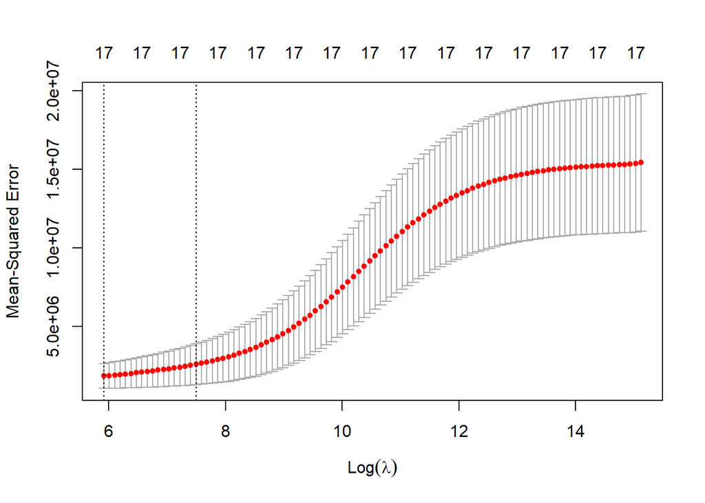

```r
cv_out <- cv.glmnet(as.matrix(training_data[,-2]),as.matrix(train_y), alpha=0)
plot(cv_out)
```

```r
#head(df_train)
```

### Best Lambda for the model

```r
best_lambda <- cv_out$lambda.min
best_lambda
```

```
## [1] 370.2356
```

#### The best lambda for the ridge model is 370.23

### Fitting a Ridge Regression Model

```r
ridge.pred <- predict(ridge.mod, s= best_lambda, type = "coefficients")

y_test_predict <- predict(ridge.mod, s = best_lambda, newx = as.matrix(testing_data[,-2]), type = "response")

test_error <- sum((y_test_predict - test_y)^2)
ridge_test_MSE <- mean((y_test_predict - test_y)^2)
```

### The test error of the model is 203767671

```r
print(test_error)
```

```
## [1] 203767671
```

### Similarly, the MSE is 1061290

```r
print(ridge_test_MSE)
```

```
## [1] 1061290
```

## (c) Fit a lasso model on the training set, with λ chosen by crossvalidation.Report the test error obtained, along with the number of non-zero coefficient estimates.

### Lasso Model

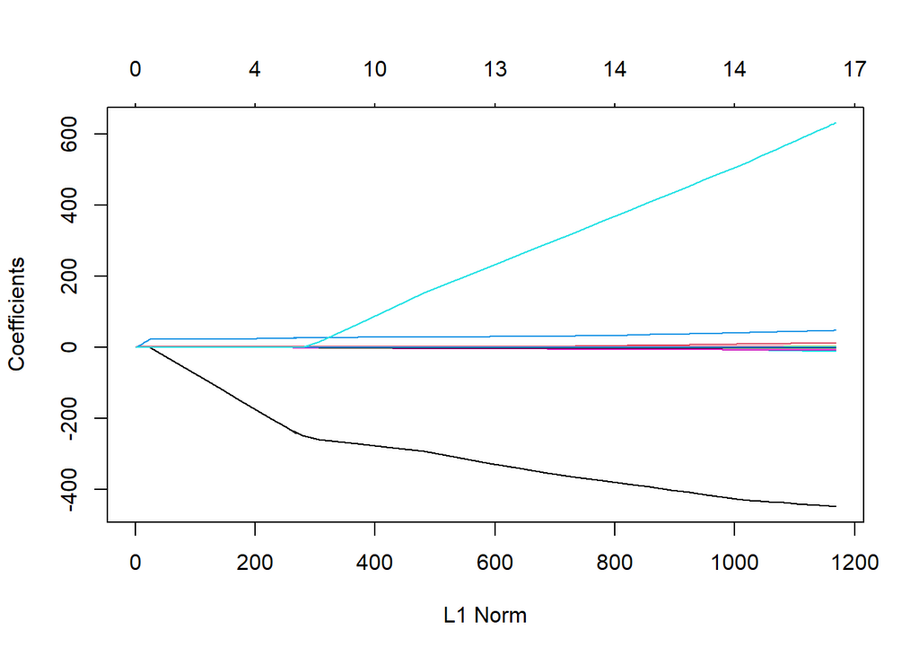

```r
lasso.mod <- glmnet(training_data[,-2], train_y, alpha=1)
plot(lasso.mod)
```

```r
cv_out_lasso = cv.glmnet(as.matrix(training_data[,-2]),as.matrix(train_y), alpha=1)
best_lambda_lasso = cv_out_lasso$lambda.min

lasso.pred <- predict(lasso.mod, s = best_lambda_lasso, type = "coefficients")

y_test_predict_lasso <- predict(lasso.mod, s = best_lambda_lasso, newx = as.matrix(testing_data[,-2]), type = "response")

test_error_lasso <- sum((y_test_predict_lasso - test_y)^2)
lasso_test_MSE <- mean((y_test_predict_lasso - test_y)^2)
```

### Best Lambda for the model is 15.298

```r
print(best_lambda_lasso)
```

```
## [1] 15.29818
```

### The test error is 174591500 and the MSE is 909330.7 respectively

```r
print(test_error_lasso)
```

```
## [1] 174591500
```

```r
print(lasso_test_MSE)
```

```
## [1] 909330.7
```

### Finding the number of Non Zero coefficients

```r
non_z = lasso.pred[1:length(lasso.mod$beta)]
length(non_z[non_z!=0])
```

```
## [1] 1162
```

## (d) Among those that are not predicted well, do you notice any common trend shared between the colleges?

### The Ridge model provides a MSE of 1061290 and the Lasso model provides a MSE of 909330.7. It shows that the Lasso model predicted the number of application better than the Ridge Model.

```r
ridge_diff = abs(y_test_predict - test_y)
lasso_diff = abs(y_test_predict_lasso - test_y)
print(ridge_diff[ridge_diff>350])
```

```
##   [1] 1494.7687  453.5889  567.8477 1990.9209 1480.4203  569.6366 2572.9309
##   [8]  775.9175  619.5262  394.2152  703.2545  852.1737  851.5367  981.0892
##  [15]  958.2204  351.0373 1302.5338  373.9607  523.9096  521.5674  350.4825
##  [22]  423.0645  592.8904  691.3723  540.7826  877.8560  385.2432 1318.2201
##  [29]  440.1786  948.5056  747.2405 2236.9435  399.1424  708.1904  751.7303
##  [36]  539.3381  499.4980  624.7035 1155.0824 2022.5300 3307.1250  639.1753
##  [43]  358.8215  367.6745  524.0090  682.8203  597.4585  667.9001  791.7970
##  [50]  470.8909  727.5542  580.6505 1483.8622 1539.1424 1538.1203 1121.3442
##  [57]  948.3353  460.5127  691.0033  360.1408  798.1655 1222.2472 2629.7535
##  [64]  615.6132 7151.6549  530.9652  958.3426  586.4455  911.7925 1771.8378
##  [71]  516.0719  595.4027  856.2067  479.4939  935.6592  465.2664  550.2479
##  [78] 2880.9339 1753.2843  415.8596 2644.3161  633.3825 1582.9271  561.2839
##  [85] 1151.6521 2868.1983  455.0103  967.7865 1995.5872  357.9766 1843.6703
##  [92]  486.5617  402.7951  816.0470  842.0680  703.2340  839.2047 2187.7053
##  [99] 1039.3401  370.8339 2426.8932  386.1905  969.8151  451.7092  589.9862
## [106] 2978.7513
```

```r
print(lasso_diff[lasso_diff>350])
```

```
##  [1] 1562.2654  503.0244 1876.9293 1607.8715  964.8883  855.5273  539.2750
##  [8] 1022.5783  910.5198 1167.0387  592.1208  950.2305 1152.7639  437.9169
## [15]  535.7455  427.9640  622.6853  506.4147 1467.4524  612.7747 1062.6919
## [22]  471.2218 1940.0182  362.0244  569.9499  561.0954  547.0122  495.2199
## [29]  545.0770  385.2153 1713.6372 3373.3023  605.8908  430.2846  622.6987
## [36]  427.0580  501.8071  416.0641  400.8577  435.7573  387.1719 1332.0094
## [43] 1346.4274 1749.5386  802.8950  633.2192  779.1762 2316.6022 7545.5423
## [50]  503.1211  764.6311  518.6628 2090.1151  403.7209  495.0767  645.5695
## [57]  483.4113  574.4580  536.9202  644.6303 1743.3620 1470.3429  472.3270
## [64]  532.9285  941.5684  748.5234  547.2771  894.2562 2174.3224 1046.7714
## [71]  951.4883 1362.4355 1488.8460 1509.1296  803.9120  674.8676  770.3542
## [78] 1629.7447 1894.3573  387.3432  836.0416  505.5480 2206.5058  866.9336
## [85]  393.0170  939.5222 3420.6878
```

```r
x1= list(which(ridge_diff>350))
x2=list(which(lasso_diff>350))
not_predicted = intersect(x1[[1]], x2[[1]])
print(not_predicted)
```

```
##  [1]   1   5   6  10  14  16  18  23  24  25  27  28  34  35  39  40  44  46  50
## [20]  51  54  55  57  58  59  60  63  64  65  66  68  70  76  86  87  94  95  96
## [39]  97  99 100 104 109 111 116 117 119 120 124 128 129 131 134 135 136 139 140
## [58] 141 143 144 149 150 156 158 159 160 161 162 166 168 169 170 171 173 181 185
## [77] 189 190 191
```

### Keeping the threshold of the difference as 350 Applications

### Colleges that are not predicted well by the models

```r
unpre <- testing_data[not_predicted,]
summary(unpre)
```

```
##     Private            Apps           Accept            Enroll
##  Min.   :0.0000   Min.   :  174   Min.   :  146.0   Min.   :  63.0
##  1st Qu.:0.0000   1st Qu.: 1438   1st Qu.:  933.5   1st Qu.: 348.5
##  Median :1.0000   Median : 2362   Median : 1951.0   Median : 700.0
##  Mean   :0.5949   Mean   : 4564   Mean   : 2972.0   Mean   :1244.3
##  3rd Qu.:1.0000   3rd Qu.: 6176   3rd Qu.: 4035.5   3rd Qu.:1664.0
##  Max.   :1.0000   Max.   :20192   Max.   :13243.0   Max.   :6392.0
##    Top10perc       Top25perc      F.Undergrad     P.Undergrad
##  Min.   : 4.00   Min.   :18.00   Min.   :  494   Min.   :   1.0
##  1st Qu.:18.00   1st Qu.:46.00   1st Qu.: 1266   1st Qu.: 105.5
##  Median :32.00   Median :66.00   Median : 3089   Median : 594.0
##  Mean   :33.24   Mean   :63.05   Mean   : 5986   Mean   :1268.5
##  3rd Qu.:43.50   3rd Qu.:79.50   3rd Qu.: 8345   3rd Qu.:1574.0
##  Max.   :95.00   Max.   :99.00   Max.   :31643   Max.   :9310.0
##     Outstate       Room.Board       Books           Personal         PhD
##  Min.   : 3648   Min.   :2190   Min.   : 300.0   Min.   : 400   Min.   :36.00
##  1st Qu.: 6827   1st Qu.:3522   1st Qu.: 500.0   1st Qu.: 910   1st Qu.:71.50
##  Median : 9766   Median :4200   Median : 525.0   Median :1258   Median :80.00
##  Mean   :10247   Mean   :4292   Mean   : 576.7   Mean   :1527   Mean   :78.23
##  3rd Qu.:13045   3rd Qu.:4822   3rd Qu.: 650.0   3rd Qu.:2000   3rd Qu.:88.50
##  Max.   :19960   Max.   :7000   Max.   :1200.0   Max.   :6800   Max.   :99.00
##     Terminal        S.F.Ratio      perc.alumni        Expend
##  Min.   : 41.00   Min.   : 4.60   Min.   : 4.00   Min.   : 3365
##  1st Qu.: 76.50   1st Qu.:11.35   1st Qu.:13.00   1st Qu.: 7493
##  Median : 87.00   Median :13.70   Median :24.00   Median : 9209
##  Mean   : 83.85   Mean   :14.03   Mean   :25.51   Mean   :11205
##  3rd Qu.: 93.50   3rd Qu.:16.80   3rd Qu.:34.50   3rd Qu.:12842
##  Max.   :100.00   Max.   :28.80   Max.   :60.00   Max.   :42926
##    Grad.Rate
##  Min.   :0.2100
##  1st Qu.:0.5550
##  Median :0.6600
##  Mean   :0.6629
##  3rd Qu.:0.7800
##  Max.   :1.0000
```

```r
#head(unpre,50)
print(range(unpre$Grad.Rate))
```

```
## [1] 0.21 1.00
```

#### **4. The Grade is very high for the Colleges. Even the 1st Quartile is 0.5550**